# Chocolate

## Question and Hypothesis

Chocolate is rated by someone who knows a lot about chocolate on a scale from 1 to 5:

```
  5 = Elite (Transcending beyond the ordinary limits)
  4 = Premium (Superior flavor development, character and style)
  3 = Satisfactory(3.0) to praiseworthy(3.75) (well made with special qualities)
  2 = Disappointing (Passable but contains at least one significant flaw)
  1 = Unpleasant (mostly unpalatable)
```

My question for this analysis is: Do ratings differ significantly from the years 2006 to 2017?

I will a Kruskal-Wallis Rank Sum test with the following formal definition of my hypothesis:
$$H_0: \text{all samples are from the same distribution}$$
$$H_a: \text{at least one sample is stochastically different}$$

I’m a level of significance of .05 kind of guy, so for this analysis the level of significance will be .05

Informally, what we are testing for is that at least one years worth of reviews differs from any of the others in a significant way. For example, maybe 2010 was a year where chocolate across the board recieved rave reviews, while the other years were only so-so. We’d have to run a statistical test to be sure, but it’s very possible that we would find that our p-value is below .05, meaning there is indeed a significant difference.

```r
pander(kruskal.test(Review ~ Rating, data = choc))
```

Kruskal-Wallis rank sum test: `Review` by `Rating`

| Test statistic | df | P value |
| --- | --- | --- |
| 133.9 | 12 | 1.001e-22 * * * |

To explore the data further, let’s look at some numbers. I think the most useful number to look at here is the “min” which stands for the minimum ratings and the “mean” column which is essentially the averge:

```r
pander(favstats(Rating ~ Review, data = choc))
```

| Review | min | Q1 | median | Q3 | max | mean | sd | n | missing |
| --- | --- | --- | --- | --- | --- | --- | --- | --- | --- |
| 2006 | 1 | 2.938 | 3 | 3.562 | 5 | 3.125 | 0.7691 | 72 | 0 |
| 2007 | 1 | 3 | 3 | 3.5 | 5 | 3.162 | 0.6998 | 77 | 0 |
| 2008 | 1 | 2.75 | 3 | 3.5 | 4 | 2.995 | 0.5442 | 93 | 0 |
| 2009 | 1.5 | 2.75 | 3 | 3.5 | 4 | 3.073 | 0.4591 | 123 | 0 |
| 2010 | 1.5 | 2.75 | 3.25 | 3.5 | 4 | 3.149 | 0.4663 | 111 | 0 |
| 2011 | 1.5 | 3 | 3.25 | 3.5 | 4 | 3.252 | 0.488 | 164 | 0 |
| 2012 | 1.5 | 2.75 | 3.25 | 3.5 | 4 | 3.178 | 0.4836 | 195 | 0 |
| 2013 | 1.75 | 2.75 | 3.25 | 3.5 | 4 | 3.197 | 0.4461 | 184 | 0 |
| 2014 | 2 | 2.875 | 3.25 | 3.5 | 4 | 3.189 | 0.4149 | 247 | 0 |
| 2015 | 2 | 3 | 3.25 | 3.5 | 4 | 3.246 | 0.3811 | 285 | 0 |
| 2016 | 2 | 3 | 3.25 | 3.5 | 4 | 3.226 | 0.4206 | 219 | 0 |
| 2017 | 2.5 | 3.25 | 3.5 | 3.5 | 3.75 | 3.312 | 0.3317 | 24 | 0 |

If you look closely, you might start to see a trend. The minimum ratings for each year either stay the same or increase from one year to the next. If a big table of numbers isn’t your thing, here’s a visual:

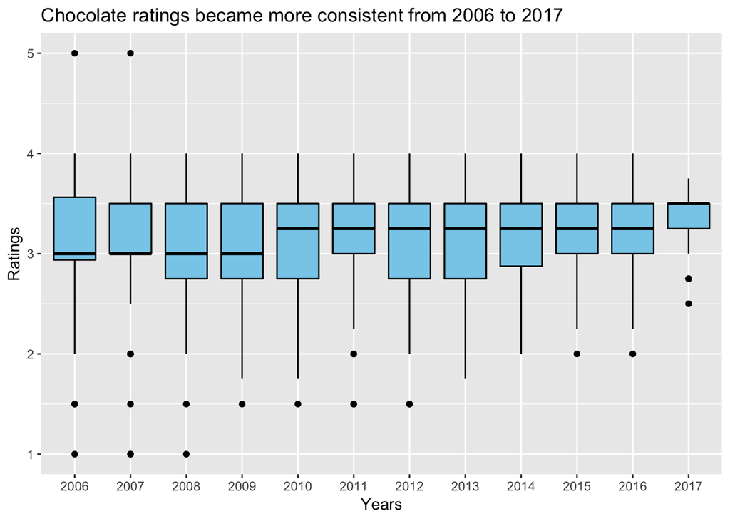

```r
ggplot(choc, aes(x=factor(Review), y=Rating)) + geom_boxplot(fill="skyblue", color="black") + labs(title="Chocolate ratings became more consistent from 2006 to 2017", x="Years", y="Ratings")
```

## Interpretation

One interpretation is both that chocolate has been becoming more consistent in it’s quality and chocolate quality has been generally increasing. Another way to look at it is that the reviewers could be simply becoming more consistent themselves on how they rate chocolate. It may be that over time, some have changed how they judge chocolate, or they agreed on a consistent standard. It could be that there are simply less reviewers making it easier to be consistent. We can’t necessarily conclude that chocolate has been getting tastier over the past decade, although it’s a possiblity judging from our Kruskal-Wallis test. I would recommend learning more about the review process as a start in gaining additional insight.